# Introduction to Computer Vision: Plant Seedlings Classification

## Problem Statement

### Context

In recent times, the field of agriculture has been in urgent need of modernizing, since the amount of manual work people need to put in to check if plants are growing correctly is still highly extensive. Despite several advances in agricultural technology, people working in the agricultural industry still need to have the ability to sort and recognize different plants and weeds, which takes a lot of time and effort in the long term. The potential is ripe for this trillion-dollar industry to be greatly impacted by technological innovations that cut down on the requirement for manual labor, and this is where Artificial Intelligence can actually benefit the workers in this field, as **the time and energy required to identify plant seedlings will be greatly shortened by the use of AI and Deep Learning.** The ability to do so far more efficiently and even more effectively than experienced manual labor, could lead to better crop yields, the freeing up of human inolvement for higher-order agricultural decision making, and in the long term will result in more sustainable environmental practices in agriculture as well.

### Objective

The aim of this project is to Build a Convolutional Neural Netowrk to classify plant seedlings into their respective categories.

### Data Dictionary

The Aarhus University Signal Processing group, in collaboration with the University of Southern Denmark, has recently released a dataset containing **images of unique plants belonging to 12 different species.**

- The dataset can be download from Olympus.
- The data file names are:
  - images.npy
  - Labels.csv
- Due to the large volume of data, the images were converted to the images.npy file and the labels are also put into Labels.csv, so that you can work on the data/project seamlessly without having to worry about the high data volume.
- The goal of the project is to create a classifier capable of determining a plant's species from an image.

**List of Species**

- Black-grass
- Charlock
- Cleavers
- Common Chickweed
- Common Wheat
- Fat Hen
- Loose Silky-bent
- Maize
- Scentless Mayweed
- Shepherds Purse
- Small-flowered Cranesbill
- Sugar beet

### **Note: Please use GPU runtime on Google Colab to execute the code faster.**

## Importing necessary libraries

```python
# Installing the libraries with the specified version.
# uncomment and run the following line if Google Colab is being used
# !pip install tensorflow==2.15.0 scikit-learn==1.2.2 seaborn==0.13.1 matplotlib==3.7.1 numpy==1.25.2 pandas==1.5.3 opencv-python==4.8.0.76 -q --user
```

```python
# Installing the libraries with the specified version.
# uncomment and run the following lines if Jupyter Notebook is being used
#!pip install tensorflow==2.13.0 scikit-learn==1.2.2 seaborn==0.11.1 matplotlib==3.3.4 numpy==1.24.3 pandas==1.5.2 opencv-python==4.8.0.76 -q --user
```

**Note**: *After running the above cell, kindly restart the notebook kernel and run all cells sequentially from the start again.*

```python
# Core Data Processing Libraries
import os                          # Operating system interfaces for file operations
import numpy as np                 # Numerical computing with multi-dimensional arrays
import pandas as pd                # Data analysis and manipulation tools
import math                        # Mathematical functions
import random                      # Random number generation and operations

# Visualization Libraries
import matplotlib.pyplot as plt    # Comprehensive plotting and visualization
import seaborn as sns              # Statistical data visualization
from google.colab.patches import cv2_imshow  # Display images in Google Colab

# Image Processing
import cv2                         # OpenCV for computer vision and image processing

# Machine Learning Libraries
from sklearn import preprocessing  # Data preprocessing tools
from sklearn.model_selection import train_test_split  # Split data into training and testing sets
from sklearn.metrics import confusion_matrix  # Evaluate classification performance
from sklearn.preprocessing import LabelBinarizer  # Transform labels to binary form
from sklearn import metrics

# Deep Learning - TensorFlow and Keras
import tensorflow as tf
from tensorflow.keras import backend  # Backend operations for Keras
from tensorflow.keras.preprocessing.image import ImageDataGenerator  # Image data augmentation
from tensorflow.keras.models import Sequential  # Sequential model API
from tensorflow.keras.layers import (
    Dense,                # Fully connected layers
    Dropout,              # Regularization layer to prevent overfitting
    Flatten,              # Flatten 2D arrays to 1D
    Conv2D,               # 2D convolutional layer
    MaxPooling2D,         # 2D pooling layer for spatial downsampling
    BatchNormalization    # Normalize layer inputs for stable learning
)
from tensorflow.keras.optimizers import Adam, SGD  # Optimization algorithms
from keras.callbacks import ReduceLROnPlateau  # Reduce learning rate when metrics plateau
from tensorflow.keras.callbacks import EarlyStopping, ModelCheckpoint, ReduceLROnPlateau

# Suppress warnings for cleaner output
import warnings
warnings.filterwarnings('ignore')
```

## Loading the dataset

```python
# Uncomment and run the below code if you are using google colab
from google.colab import drive
drive.mount('/content/drive')
```

```python
# Load the images to dataframe
ps_images = np.load('/content/drive/MyDrive/Colab Notebooks/PGP-AIML/Partha/Computer Vision Project/images.npy')
# Load the labels into dataframe
ps_labels = pd.read_csv('/content/drive/MyDrive/Colab Notebooks/PGP-AIML/Partha/Computer Vision Project/Labels.csv')
```

```python
# Create a copy of the original BGR images to preserve them
ps_images_orig = ps_images.copy()  # Make a deep copy of the original data
ps_labels_orig = ps_labels.copy()
```

## Data Overview

### Understand the shape of the dataset

```python
# Shape of images
print('Shape of images:', ps_images.shape)
# Shape of labels
print('Shape of labels:', ps_labels.shape)
```

```
Shape of images: (4750, 128, 128, 3)
Shape of labels: (4750, 1)
```

#### **Observation**

- There are 4750 images, each image is 128x128 pixels in size
- Thre are 3 channels for each image

```python
#Let's check the data
ps_labels.head()
```

|  | Label |
| --- | --- |
| 0 | Small-flowered Cranesbill |
| 1 | Small-flowered Cranesbill |
| 2 | Small-flowered Cranesbill |
| 3 | Small-flowered Cranesbill |
| 4 | Small-flowered Cranesbill |

```python
ps_labels.tail()
```

|  | Label |
| --- | --- |
| 4745 | Loose Silky-bent |
| 4746 | Loose Silky-bent |
| 4747 | Loose Silky-bent |
| 4748 | Loose Silky-bent |
| 4749 | Loose Silky-bent |

#### **Observation**

- The data is loaded properly

### Check for missing data

```python
# Let's check if there are any missing data in label
ps_labels.isnull().sum()
```

|  | 0 |
| --- | --- |
| Label | 0 |

**dtype:** int64

```python
# Let's check if there are any missing data in images
# Check for NaN values in the images array
print("Number of NaN values in images:", np.isnan(ps_images).sum())
# Check for inf values in the images array
print("Number of inf values in images:", np.isinf(ps_images).sum())
```

```
Number of NaN values in images: 0
Number of inf values in images: 0
```

#### **Observation**

- There are no missing values

### Check for different plants in the dataset

```python
# Let's Check for different plants in the dataset.
print(ps_labels['Label'].unique())
print(ps_labels['Label'].nunique())
ps_labels['Label'].value_counts()
```

```
['Small-flowered Cranesbill' 'Fat Hen' 'Shepherds Purse' 'Common wheat'
 'Common Chickweed' 'Charlock' 'Cleavers' 'Scentless Mayweed' 'Sugar beet'
 'Maize' 'Black-grass' 'Loose Silky-bent']
12
```

| Label | count |
| --- | --- |
| Loose Silky-bent | 654 |
| Common Chickweed | 611 |
| Scentless Mayweed | 516 |
| Small-flowered Cranesbill | 496 |
| Fat Hen | 475 |
| Charlock | 390 |
| Sugar beet | 385 |
| Cleavers | 287 |
| Black-grass | 263 |
| Shepherds Purse | 231 |
| Common wheat | 221 |
| Maize | 221 |

**dtype:** int64

#### **Observation**

- 12 different plant species with a total of 4,750 images. The class distribution is not perfectly balanced

### Plotting images using OpenCV and matplotlib

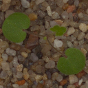

```python
cv2_imshow(ps_images[79])
```

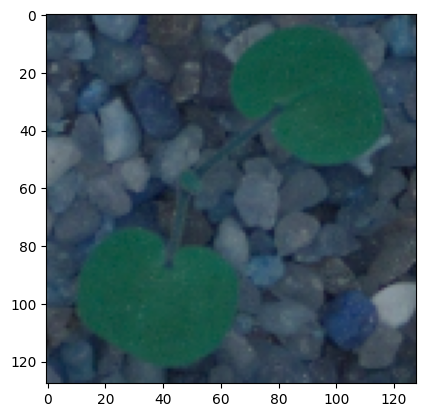

```python
plt.imshow(ps_images[100])
```

#### **Observation**

- The color discrepancy between OpenCV and matplotlib visualizations indicates that the numpy arrays were originally created using OpenCV.
- This discrepancy occurs because OpenCV reads images in BGR (Blue-Green-Red) format while matplotlib uses the standard RGB (Red-Green-Blue) format.
- To ensure accurate and intuitive visual interpretation of the plant seedling images throughout our analysis, we will convert the dataset from BGR to RGB format.

## Exploratory Data Analysis

- EDA is an important part of any project involving data.
- It is important to investigate and understand the data better before building a model with it.
- A few questions have been mentioned below which will help you understand the data better.
- A thorough analysis of the data, in addition to the questions mentioned below, should be done.
1. How are these different category plant images different from each other?
2. Is the dataset provided an imbalance? (Check with using bar plots)

### Plot Random Images from each of the class

**Helper Class**

```python
def plot_images(images,labels):
  num_classes=10                                                                  # Number of Classes
  categories=np.unique(labels)
  keys=dict(labels['Label'])                                                      # Obtaing the unique classes from y_train
  rows = 3                                                                        # Defining number of rows=3
  cols = 4                                                                        # Defining number of columns=4
  fig = plt.figure(figsize=(10, 8))                                               # Defining the figure size to 10x8
  for i in range(cols):
      for j in range(rows):
          random_index = np.random.randint(0, len(labels))                        # Generating random indices from the data and plotting the images
          ax = fig.add_subplot(rows, cols, i * rows + j + 1)                      # Adding subplots with 3 rows and 4 columns
          ax.imshow(images[random_index, :])                                      # Plotting the image
          ax.set_title(keys[random_index])
  plt.show()
```

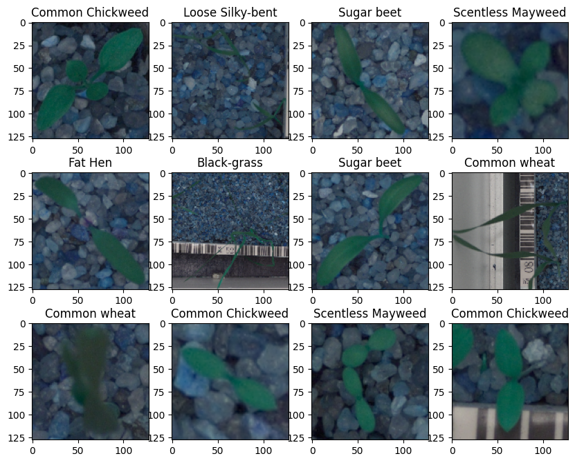

```python
## Plot the images
plot_images(ps_images,ps_labels)
```

### Checking for data imbalance

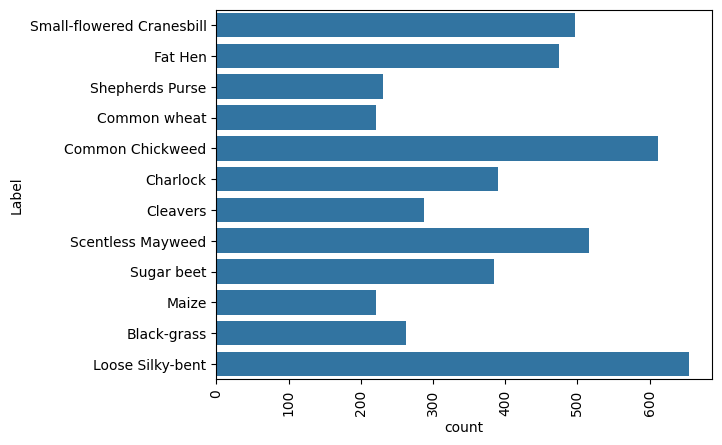

```python
# Plot a countplot to visualize the distribution of plant species in our dataset
sns.countplot(ps_labels['Label']);
plt.xticks(rotation='vertical');  # Rotate x-axis labels vertically for better readability
```

## Data Pre-Processing

### Convert the BGR images to RGB images.

```
Converting images from BGR to RGB format...
```

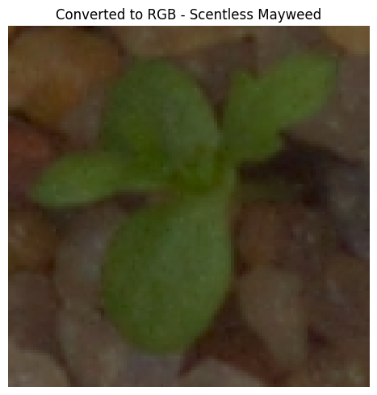

```
RGB conversion complete. Images are now in RGB format for proper visualization.
```

```python
# Convert BGR images to RGB using OpenCV
print("Converting images from BGR to RGB format...")

# Create a copy of the original BGR images to preserve them
ps_images_rgb = ps_images.copy()  # Make a deep copy of the original data

# Loop through each image in the dataset
for i in range(len(ps_images)):
    # Apply OpenCV's color conversion function to transform BGR to RGB
    ps_images[i] = cv2.cvtColor(ps_images[i], cv2.COLOR_BGR2RGB)

# Verify the conversion by displaying a sample image before and after
plt.figure(figsize=(10, 5))

# Select a random image to verify the conversion
sample_idx = np.random.randint(0, len(ps_images))
sample_label = ps_labels['Label'][sample_idx]

# Display the converted RGB image
plt.imshow(ps_images[sample_idx])
plt.title(f"Converted to RGB - {sample_label}")
plt.axis('off')

plt.tight_layout()
plt.show()

print("RGB conversion complete. Images are now in RGB format for proper visualization.")
```

### Resize the images

As the size of the images is large, it may be computationally expensive to train on these larger images; therefore, it is preferable to reduce the image size from 128 to 64.

```python
# Create an empty list to store resized images
resized_ps_images = []

# Define target dimensions for the resized images
target_height = 64
target_width = 64
target_dimensions = (target_width, target_height)

# Track the start time to estimate total processing time
import time
start_time = time.time()

# Loop through each image in the dataset to resize
for i in range(len(ps_images)):
    # Resize the image using OpenCV's resize function with linear interpolation
    resized_image = cv2.resize(ps_images[i], target_dimensions, interpolation=cv2.INTER_LINEAR)

    # Add the resized image to our collection
    resized_ps_images.append(resized_image)

# Convert the list to a numpy array for better performance with deep learning libraries
resized_ps_images = np.array(resized_ps_images)

# Print the shape of the resized images array
print(f"Original images shape: {ps_images.shape}")
print(f"Resized images shape: {resized_ps_images.shape}")
```

```
Original images shape: (4750, 128, 128, 3)
Resized images shape: (4750, 64, 64, 3)
```

**Original Image**

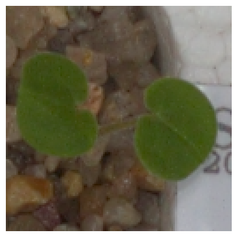

```python
# Print original image
plt.figure(figsize=(10, 5))
plt.imshow(ps_images[36])
plt.axis('off')
plt.show()
```

**Resized Image**

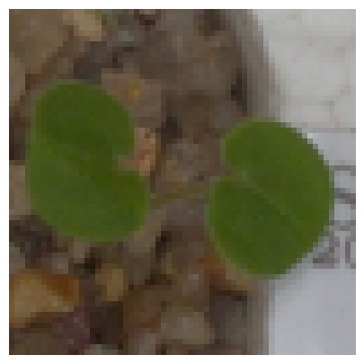

```python
# Print random resized image
plt.figure(figsize=(10, 5))
plt.imshow(resized_ps_images[36])
plt.axis('off')
plt.show()
```

#### **Observation**

- Original images shape: (4750, 128, 128, 3)
- Resized images shape: (4750, 64, 64, 3)
- Reducing the size had degraded the image quality, we might use the original size to build a model for comparision

### Data Preparation for Modeling

- Before you proceed to build a model, you need to split the data into train, test, and validation to be able to evaluate the model that you build on the train data
- You'll have to encode categorical features and scale the pixel values.
- You will build a model using the train data and then check its performance

**Split the dataset**

```python
# Split dataset
# Set a random seed for reproducibility
RANDOM_SEED = 42

# Print the shape of the original dataset before splitting
print("Original dataset shape:")
print(f"resized_ps_images shape: {resized_ps_images.shape}")
print(f"labels shape: {ps_labels.shape}")
print("-" * 50)

# First split the data into a temporary train set and test set (80% train+val, 20% test)
X_temp, X_test, y_temp, y_test = train_test_split(
    resized_ps_images,        # Your resized images
    ps_labels['Label'],          # The labels
    test_size=0.2,            # 20% of data will be the test set
    random_state=RANDOM_SEED, # For reproducible results
    stratify=ps_labels['Label']  # Ensure class distribution is preserved
)

# Next, split the temporary train set into final train and validation sets
X_train, X_val, y_train, y_val = train_test_split(
    X_temp,                   # The 80% temporary training data
    y_temp,                   # The 80% temporary labels
    test_size=0.25,           # 25% of 80% = 20% of the original data for validation
    random_state=RANDOM_SEED, # Same seed for consistency
    stratify=y_temp           # Maintain class distribution in the split
)

# Check the shapes of the resulting datasets
print("Split dataset shapes:")
print("-" * 50)
print(f"X_train shape: {X_train.shape}")
print(f"y_train shape: {y_train.shape}")
print(f"X_val shape: {X_val.shape}")
print(f"y_val shape: {y_val.shape}")
print(f"X_test shape: {X_test.shape}")
print(f"y_test shape: {y_test.shape}")
print("-" * 50)

# Verify the proportion of the split
total_samples = len(resized_ps_images)
print(f"\nSplit proportions:")
print(f"Training: {len(X_train)/total_samples:.2%} ({len(X_train)} images)")
print(f"Validation: {len(X_val)/total_samples:.2%} ({len(X_val)} images)")
print(f"Testing: {len(X_test)/total_samples:.2%} ({len(X_test)} images)")
print(f"Total: {(len(X_train) + len(X_val) + len(X_test))/total_samples:.2%} ({len(X_train) + len(X_val) + len(X_test)} images)")
```

```
Original dataset shape:
resized_ps_images shape: (4750, 64, 64, 3)
labels shape: (4750, 1)
--------------------------------------------------
Split dataset shapes:
--------------------------------------------------
X_train shape: (2850, 64, 64, 3)
y_train shape: (2850,)
X_val shape: (950, 64, 64, 3)
y_val shape: (950,)
X_test shape: (950, 64, 64, 3)
y_test shape: (950,)
--------------------------------------------------

Split proportions:
Training: 60.00% (2850 images)
Validation: 20.00% (950 images)
Testing: 20.00% (950 images)
Total: 100.00% (4750 images)
```

#### **Observation**

- Original Dataset Shape
  - **resized_ps_images shape:** (4750, 64, 64, 3)
  - **labels shape:** (4750, 1)
- Split Dataset Shapes
  - **X_train shape:** (2850, 64, 64, 3)
  - **y_train shape:** (2850,)
  - **X_val shape:** (950, 64, 64, 3)
  - **y_val shape:** (950,)
  - **X_test shape:** (950, 64, 64, 3)
  - **y_test shape:** (950,)
- Split Proportions
  - **Training:** 60.00% (2850 images)
  - **Validation:** 20.00% (950 images)
  - **Testing:** 20.00% (950 images)
  - **Total:** 100.00% (4750 images)

### Encode the target labels

```python
# Convert labels from names to one hot vectors.
# Step 1: Initialize the LabelBinarizer
label_binarizer = LabelBinarizer()

# Step 2: Fit the binarizer on all labels to ensure consistent encoding
label_binarizer.fit(np.concatenate([y_train, y_val, y_test]))

# Step 3: Transform labels to binary form
y_train_binary = label_binarizer.transform(y_train)
y_val_binary = label_binarizer.transform(y_val)
y_test_binary = label_binarizer.transform(y_test)

# Store the classes for future reference
classes = label_binarizer.classes_
print("Encoded classes mapping:")
for i, class_name in enumerate(classes):
    print(f"{i}: {class_name}")

# Print the shapes to verify the encoding
print("\nBinarized label shapes:")
print(f"y_train_binary shape: {y_train_binary.shape}")
print(f"y_val_binary shape: {y_val_binary.shape}")
print(f"y_test_binary shape: {y_test_binary.shape}")

# Example of original vs binarized encoding
print("\nExample of label binarization:")
print(f"Original label: {y_train.iloc[0]}")
print(f"Class index: {np.where(y_train_binary[0] == 1)[0][0]}")
print(f"Binarized label: {y_train_binary[0]}")
```

```
Encoded classes mapping:
0: Black-grass
1: Charlock
2: Cleavers
3: Common Chickweed
4: Common wheat
5: Fat Hen
6: Loose Silky-bent
7: Maize
8: Scentless Mayweed
9: Shepherds Purse
10: Small-flowered Cranesbill
11: Sugar beet

Binarized label shapes:
y_train_binary shape: (2850, 12)
y_val_binary shape: (950, 12)
y_test_binary shape: (950, 12)

Example of label binarization:
Original label: Charlock
Class index: 1
Binarized label: [0 1 0 0 0 0 0 0 0 0 0 0]
```

#### **Observation**

- Encoded classes mapping:
  - 0: Black-grass
  - 1: Charlock
  - 2: Cleavers
  - 3: Common Chickweed
  - 4: Common wheat
  - 5: Fat Hen
  - 6: Loose Silky-bent
  - 7: Maize
  - 8: Scentless Mayweed
  - 9: Shepherds Purse
  - 10: Small-flowered Cranesbill
  - 11: Sugar beet
- Binarized label shapes:
  - y_train_binary shape: (2850, 12)
  - y_val_binary shape: (950, 12)
  - y_test_binary shape: (950, 12)
- Example of label binarization:
  - Original label: Charlock
  - Class index: 1
  - Binarized label: [0 1 0 0 0 0 0 0 0 0 0 0]

### Data Normalization

```
Before normalization:
X_train dtype: uint8
X_train min value: 0
X_train max value: 255

After normalization:
X_train_normalized dtype: float32
X_train_normalized min value: 0.0
X_train_normalized max value: 1.0
```

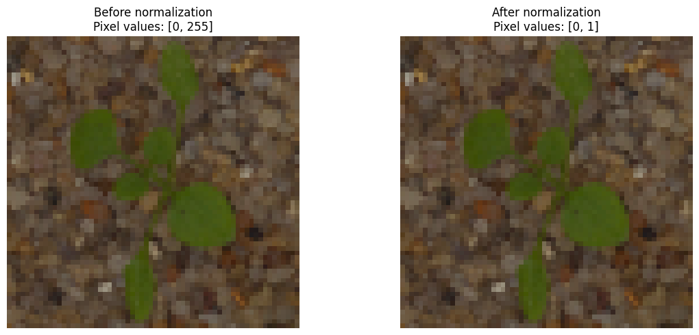

```
Normalization complete. All image data is now in the range [0, 1].
```

```python
# Normalize the pixel values of the images to the range [0, 1]
# Original pixel values are typically 0-255 (uint8)

# Print the data type and range before normalization
print("Before normalization:")
print(f"X_train dtype: {X_train.dtype}")
print(f"X_train min value: {X_train.min()}")
print(f"X_train max value: {X_train.max()}")

# Normalize by dividing by 255.0 (the maximum pixel value)
X_train_normalized = X_train.astype('float32') / 255.0
X_val_normalized = X_val.astype('float32') / 255.0
X_test_normalized = X_test.astype('float32') / 255.0

# Print the data type and range after normalization
print("\nAfter normalization:")
print(f"X_train_normalized dtype: {X_train_normalized.dtype}")
print(f"X_train_normalized min value: {X_train_normalized.min()}")
print(f"X_train_normalized max value: {X_train_normalized.max()}")

# Verify normalization by displaying a sample image before and after
plt.figure(figsize=(12, 5))

# Display an image before normalization
plt.subplot(1, 2, 1)
sample_idx = 36
plt.imshow(X_train[sample_idx])
plt.title(f"Before normalization\nPixel values: [0, 255]")
plt.axis('off')

# Display the same image after normalization
plt.subplot(1, 2, 2)
plt.imshow(X_train_normalized[sample_idx])
plt.title(f"After normalization\nPixel values: [0, 1]")
plt.axis('off')

plt.tight_layout()
plt.show()

# # Reassign the normalized arrays to the original variable names if desired
# X_train = X_train_normalized
# X_val = X_val_normalized
# X_test = X_test_normalized

print("\nNormalization complete. All image data is now in the range [0, 1].")
```

## Model Building

### **Model 1**

```python
# Clearing backend
backend.clear_session()
```

```python
# Fixing the seed for random number generators
np.random.seed(124)
random.seed(124)
tf.random.set_seed(124)
```

```python
# Define input shape
input_shape = (64, 64, 3)

# Create the CNN model
model1 = Sequential()

# First convolutional block
model1.add(Conv2D(32, kernel_size=(3, 3), activation='relu', padding='same', input_shape=input_shape))
model1.add(MaxPooling2D(pool_size=(2, 2)))

# Second convolutional block
model1.add(Conv2D(64, kernel_size=(3, 3), activation='relu', padding='same'))
model1.add(MaxPooling2D(pool_size=(2, 2)))

# Third convolutional block
model1.add(Conv2D(96, kernel_size=(3, 3), activation='relu', padding='same'))
model1.add(MaxPooling2D(pool_size=(2, 2)))

# Fourth convolutional block - this will reduce to 4x4 feature maps
model1.add(Conv2D(128, kernel_size=(3, 3), activation='relu', padding='same'))
model1.add(MaxPooling2D(pool_size=(2, 2)))

# Flatten the feature maps
model1.add(Flatten())

# Fully connected layers
model1.add(Dense(100, activation='relu'))
model1.add(Dropout(0.3))
model1.add(Dense(100, activation='relu'))

# Output layer with 12 neurons (one for each plant class)
model1.add(Dense(12, activation='softmax'))

# Compile the model
model1.compile(
    optimizer=Adam(learning_rate=0.001),
    loss='categorical_crossentropy',
    metrics=['accuracy']
)

# Print model summary
model1.summary()
```

```
Model: "sequential"
```

```
┏━━━━━━━━━━━━━━━━━━━━━━━━━━━━━━━━━━━━━━┳━━━━━━━━━━━━━━━━━━━━━━━━━━━━━┳━━━━━━━━━━━━━━━━━┓
┃ Layer (type)                         ┃ Output Shape                ┃         Param # ┃
┡━━━━━━━━━━━━━━━━━━━━━━━━━━━━━━━━━━━━━━╇━━━━━━━━━━━━━━━━━━━━━━━━━━━━━╇━━━━━━━━━━━━━━━━━┩
│ conv2d (Conv2D)                      │ (None, 64, 64, 32)          │             896 │
├──────────────────────────────────────┼─────────────────────────────┼─────────────────┤
│ max_pooling2d (MaxPooling2D)         │ (None, 32, 32, 32)          │               0 │
├──────────────────────────────────────┼─────────────────────────────┼─────────────────┤
│ conv2d_1 (Conv2D)                    │ (None, 32, 32, 64)          │          18,496 │
├──────────────────────────────────────┼─────────────────────────────┼─────────────────┤
│ max_pooling2d_1 (MaxPooling2D)       │ (None, 16, 16, 64)          │               0 │
├──────────────────────────────────────┼─────────────────────────────┼─────────────────┤
│ conv2d_2 (Conv2D)                    │ (None, 16, 16, 96)          │          55,392 │
├──────────────────────────────────────┼─────────────────────────────┼─────────────────┤
│ max_pooling2d_2 (MaxPooling2D)       │ (None, 8, 8, 96)            │               0 │
├──────────────────────────────────────┼─────────────────────────────┼─────────────────┤
│ conv2d_3 (Conv2D)                    │ (None, 8, 8, 128)           │         110,720 │
├──────────────────────────────────────┼─────────────────────────────┼─────────────────┤
│ max_pooling2d_3 (MaxPooling2D)       │ (None, 4, 4, 128)           │               0 │
├──────────────────────────────────────┼─────────────────────────────┼─────────────────┤
│ flatten (Flatten)                    │ (None, 2048)                │               0 │
├──────────────────────────────────────┼─────────────────────────────┼─────────────────┤
│ dense (Dense)                        │ (None, 100)                 │         204,900 │
├──────────────────────────────────────┼─────────────────────────────┼─────────────────┤
│ dropout (Dropout)                    │ (None, 100)                 │               0 │
├──────────────────────────────────────┼─────────────────────────────┼─────────────────┤
│ dense_1 (Dense)                      │ (None, 100)                 │          10,100 │
├──────────────────────────────────────┼─────────────────────────────┼─────────────────┤
│ dense_2 (Dense)                      │ (None, 12)                  │           1,212 │
└──────────────────────────────────────┴─────────────────────────────┴─────────────────┘
```

```
 Total params: 401,716 (1.53 MB)
```

```
 Trainable params: 401,716 (1.53 MB)
```

```
 Non-trainable params: 0 (0.00 B)
```

**Fitting the model on the train data**

```python
# Calculate appropriate batch size
# We want at least 50 batches per epoch
total_training_samples = len(X_train)
batch_size = total_training_samples // 50
# Ensure batch size is not too large
batch_size = min(batch_size, 64)
print(f"Training samples: {total_training_samples}")
print(f"Batch size: {batch_size}")
print(f"Steps per epoch: {total_training_samples // batch_size}")
```

```
Training samples: 2850
Batch size: 57
Steps per epoch: 50
```

```python
# Early stopping to prevent overfitting
early_stopping = EarlyStopping(
    monitor='val_loss',
    patience=10,  # Number of epochs with no improvement after which training will stop
    verbose=1,
    restore_best_weights=True  # Restores model weights from the epoch with the best value of the monitored quantity
)
```

```python
# Fit the model on train and validation data.
history_1 = model1.fit(
            X_train_normalized, y_train_binary,
            epochs=100,
            validation_data=(X_val_normalized,y_val_binary),
            batch_size=64,
            callbacks=[early_stopping],
            verbose=2
)
```

```
45/45 - 13s - 293ms/step - accuracy: 0.1256 - loss: 2.4420 - val_accuracy: 0.1284 - val_loss: 2.4147
45/45 - 0s - 7ms/step - accuracy: 0.1614 - loss: 2.4053 - val_accuracy: 0.2253 - val_loss: 2.2664
45/45 - 0s - 7ms/step - accuracy: 0.2933 - loss: 2.0441 - val_accuracy: 0.3589 - val_loss: 1.7332
45/45 - 0s - 7ms/step - accuracy: 0.3839 - loss: 1.7442 - val_accuracy: 0.4463 - val_loss: 1.5216
45/45 - 0s - 7ms/step - accuracy: 0.4463 - loss: 1.5365 - val_accuracy: 0.5137 - val_loss: 1.3300
45/45 - 0s - 7ms/step - accuracy: 0.4954 - loss: 1.4017 - val_accuracy: 0.5684 - val_loss: 1.2021
45/45 - 0s - 7ms/step - accuracy: 0.5495 - loss: 1.2473 - val_accuracy: 0.5884 - val_loss: 1.1114
45/45 - 0s - 7ms/step - accuracy: 0.5814 - loss: 1.1566 - val_accuracy: 0.6063 - val_loss: 1.1113
45/45 - 0s - 7ms/step - accuracy: 0.6102 - loss: 1.0944 - val_accuracy: 0.6337 - val_loss: 1.0361
45/45 - 0s - 7ms/step - accuracy: 0.6400 - loss: 1.0154 - val_accuracy: 0.6568 - val_loss: 0.9512
45/45 - 0s - 7ms/step - accuracy: 0.6611 - loss: 0.9725 - val_accuracy: 0.6905 - val_loss: 0.9190
45/45 - 0s - 7ms/step - accuracy: 0.6856 - loss: 0.8992 - val_accuracy: 0.6674 - val_loss: 0.9755
45/45 - 0s - 7ms/step - accuracy: 0.7182 - loss: 0.8315 - val_accuracy: 0.6884 - val_loss: 0.9310
45/45 - 0s - 7ms/step - accuracy: 0.6884 - loss: 0.8838 - val_accuracy: 0.7663 - val_loss: 0.7340
45/45 - 0s - 7ms/step - accuracy: 0.7277 - loss: 0.7645 - val_accuracy: 0.7611 - val_loss: 0.7329
45/45 - 0s - 7ms/step - accuracy: 0.7502 - loss: 0.7144 - val_accuracy: 0.7516 - val_loss: 0.7208
45/45 - 0s - 7ms/step - accuracy: 0.7386 - loss: 0.7336 - val_accuracy: 0.7579 - val_loss: 0.7174
45/45 - 0s - 7ms/step - accuracy: 0.7523 - loss: 0.6787 - val_accuracy: 0.7632 - val_loss: 0.7144
45/45 - 0s - 7ms/step - accuracy: 0.7418 - loss: 0.7512 - val_accuracy: 0.7600 - val_loss: 0.7106
45/45 - 0s - 7ms/step - accuracy: 0.7614 - loss: 0.6825 - val_accuracy: 0.7411 - val_loss: 0.7503
45/45 - 0s - 7ms/step - accuracy: 0.7611 - loss: 0.6460 - val_accuracy: 0.7695 - val_loss: 0.6770
45/45 - 0s - 7ms/step - accuracy: 0.7979 - loss: 0.5711 - val_accuracy: 0.7579 - val_loss: 0.7203
45/45 - 0s - 7ms/step - accuracy: 0.7912 - loss: 0.5941 - val_accuracy: 0.7779 - val_loss: 0.6656
45/45 - 0s - 7ms/step - accuracy: 0.8179 - loss: 0.5186 - val_accuracy: 0.7853 - val_loss: 0.7042
45/45 - 0s - 7ms/step - accuracy: 0.8439 - loss: 0.4546 - val_accuracy: 0.7989 - val_loss: 0.6165
45/45 - 0s - 7ms/step - accuracy: 0.8277 - loss: 0.4681 - val_accuracy: 0.7958 - val_loss: 0.6445
45/45 - 0s - 7ms/step - accuracy: 0.8502 - loss: 0.4183 - val_accuracy: 0.8032 - val_loss: 0.6604
45/45 - 0s - 7ms/step - accuracy: 0.8593 - loss: 0.3958 - val_accuracy: 0.7905 - val_loss: 0.6340
45/45 - 0s - 7ms/step - accuracy: 0.8621 - loss: 0.3962 - val_accuracy: 0.8063 - val_loss: 0.6088
45/45 - 0s - 7ms/step - accuracy: 0.8740 - loss: 0.3641 - val_accuracy: 0.8021 - val_loss: 0.6499
45/45 - 0s - 7ms/step - accuracy: 0.8688 - loss: 0.3559 - val_accuracy: 0.7842 - val_loss: 0.6584
45/45 - 0s - 7ms/step - accuracy: 0.8744 - loss: 0.3297 - val_accuracy: 0.7611 - val_loss: 0.8202
45/45 - 0s - 7ms/step - accuracy: 0.8618 - loss: 0.3749 - val_accuracy: 0.7874 - val_loss: 0.7610
45/45 - 0s - 7ms/step - accuracy: 0.8811 - loss: 0.3179 - val_accuracy: 0.7874 - val_loss: 0.7472
45/45 - 0s - 7ms/step - accuracy: 0.8835 - loss: 0.3117 - val_accuracy: 0.7895 - val_loss: 0.7931
45/45 - 0s - 7ms/step - accuracy: 0.8782 - loss: 0.3154 - val_accuracy: 0.8000 - val_loss: 0.7496
45/45 - 0s - 7ms/step - accuracy: 0.8877 - loss: 0.3080 - val_accuracy: 0.7853 - val_loss: 0.7503
45/45 - 0s - 7ms/step - accuracy: 0.8888 - loss: 0.2953 - val_accuracy: 0.7884 - val_loss: 0.7650
45/45 - 0s - 7ms/step - accuracy: 0.8937 - loss: 0.2890 - val_accuracy: 0.7968 - val_loss: 0.7457
Epoch 39: early stopping
Restoring model weights from the end of the best epoch: 29.
```

**Model Evaluation**

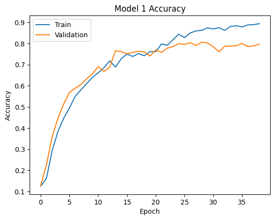

```python
# Plot the loss and accuracy of the model.
plt.plot(history_1.history['accuracy'])
plt.plot(history_1.history['val_accuracy'])
plt.title('Model 1 Accuracy')
plt.ylabel('Accuracy')
plt.xlabel('Epoch')
plt.legend(['Train', 'Validation'], loc='upper left')
plt.show()
```

#### **Observation**

- **Healthy Learning Curve:** Both training and validation accuracies show steady improvement throughout training, which indicates good model learning.
- **Final Performance:** The model achieves approximately 88% training accuracy and 78-80% validation accuracy, which is solid for a 12-class plant seedling classification task.
- **Minimal Overfitting:** There's only about a 10% gap between training and validation accuracy at the end of training, suggesting reasonable generalization.
- **Interesting Pattern:** During epochs 15-23, validation accuracy was actually higher than training accuracy - this unusual pattern might indicate effective regularization techniques or possibly some randomness in the validation set evaluation.
- **Good Convergence:** The learning curves flatten after about epoch 25, indicating the model has converged to a stable solution.

**Evaluating the model on test data**

```python
# Evaluate the model on the test data
accuracy = model1.evaluate(X_test_normalized, y_test_binary, verbose=2)
```

```
30/30 - 3s - 109ms/step - accuracy: 0.8116 - loss: 0.6344
```

**Plotting the Confusion Matrix**

```python
# Get the output as probablities for each category.
y_pred=model1.predict(X_test_normalized)
```

```
30/30 ━━━━━━━━━━━━━━━━━━━━ 1s 22ms/step
```

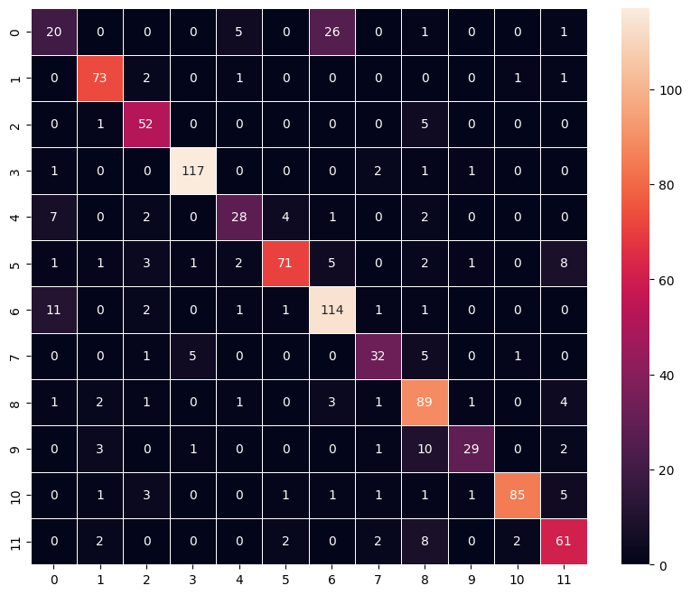

```python
# Obtaining the categorical values from y_test_binary and y_pred
y_pred_arg=np.argmax(y_pred,axis=1)
y_test_arg=np.argmax(y_test_binary,axis=1)

# Plotting the Confusion Matrix using confusion matrix() function which is also predefined tensorflow module
confusion_matrix = tf.math.confusion_matrix(y_test_arg,y_pred_arg)
f, ax = plt.subplots(figsize=(10, 8))
sns.heatmap(
    confusion_matrix,
    annot=True,
    linewidths=.4,
    fmt="d",
    square=True,
    ax=ax
)
plt.show()
```

**Plotting Classification Report**

```python
# Plotting the classification report
print("Model 1 Classification Report")
cr=metrics.classification_report(y_test_arg,y_pred_arg)
print(cr)
```

```
Model 1 Classification Report
              precision    recall  f1-score   support

           0       0.49      0.38      0.43        53
           1       0.88      0.94      0.91        78
           2       0.79      0.90      0.84        58
           3       0.94      0.96      0.95       122
           4       0.74      0.64      0.68        44
           5       0.90      0.75      0.82        95
           6       0.76      0.87      0.81       131
           7       0.80      0.73      0.76        44
           8       0.71      0.86      0.78       103
           9       0.88      0.63      0.73        46
          10       0.96      0.86      0.90        99
          11       0.74      0.79      0.77        77

    accuracy                           0.81       950
   macro avg       0.80      0.77      0.78       950
weighted avg       0.81      0.81      0.81       950
```

## Model Performance Improvement

**Reducing the Learning Rate:**

**Hint**: Use **ReduceLRonPlateau()** function that will be used to decrease the learning rate by some factor, if the loss is not decreasing for some time. This may start decreasing the loss at a smaller learning rate. There is a possibility that the loss may still not decrease. This may lead to executing the learning rate reduction again in an attempt to achieve a lower loss.

```python
# Reduce learning rate when a metric has stopped improving
reduce_lr = ReduceLROnPlateau(
    monitor='val_loss',
    factor=0.2,  # multiply the learning rate by 0.2 (reduce by 80%)
    patience=5,  # number of epochs with no improvement after which learning rate will be reduced
    min_lr=1e-6,
    verbose=1
)
```

### **Model 2**

1. Takes input images of shape (64, 64, 3)
2. Uses 3x3 kernels for all convolutional layers as specified
3. Includes 4 convolutional blocks, each reducing spatial dimensions until you reach 4x4 feature maps
4. Starting with 64x64 → 32x32 → 16x16 → 8x8 → 4x4
5. Uses increasing filter counts (32, 64, 96, 128) to extract more complex features
6. Incorporates BatchNormalization for faster training and better generalization
7. Uses Dropout to prevent overfitting
8. Has two dense layers before the final output layer 1.Uses softmax activation for multi-class classification with 12 output neurons
9. Is compiled with Adam optimizer and categorical crossentropy loss

```python
# Clearing backend
backend.clear_session()
```

```python
# Fixing the seed for random number generators
np.random.seed(124)
random.seed(124)
tf.random.set_seed(124)
```

```python
# Define input shape
input_shape = (64, 64, 3)

# Create the CNN model
model2 = Sequential()

# First convolutional block
model2.add(Conv2D(32, kernel_size=(3, 3), activation='relu', padding='same', input_shape=input_shape))
model2.add(BatchNormalization())
model2.add(MaxPooling2D(pool_size=(2, 2)))
model2.add(Dropout(0.25))

# Second convolutional block
model2.add(Conv2D(64, kernel_size=(3, 3), activation='relu', padding='same'))
model2.add(BatchNormalization())
model2.add(MaxPooling2D(pool_size=(2, 2)))
model2.add(Dropout(0.25))

# Third convolutional block
model2.add(Conv2D(96, kernel_size=(3, 3), activation='relu', padding='same'))
model2.add(BatchNormalization())
model2.add(MaxPooling2D(pool_size=(2, 2)))
model2.add(Dropout(0.25))

# Fourth convolutional block - this will reduce to 4x4 feature maps
model2.add(Conv2D(128, kernel_size=(3, 3), activation='relu', padding='same'))
model2.add(BatchNormalization())
model2.add(MaxPooling2D(pool_size=(2, 2)))
model2.add(Dropout(0.25))

# Flatten the feature maps
model2.add(Flatten())

# Fully connected layers
model2.add(Dense(100, activation='relu'))
model2.add(BatchNormalization())
model2.add(Dropout(0.5))
model2.add(Dense(100, activation='relu'))
model2.add(BatchNormalization())
model2.add(Dropout(0.5))

# Output layer with 12 neurons (one for each plant class)
model2.add(Dense(12, activation='softmax'))

# Compile the model
model2.compile(
    optimizer=Adam(learning_rate=0.001),
    loss='categorical_crossentropy',
    metrics=['accuracy']
)

# Print model summary
model2.summary()
```

```
Model: "sequential"
```

```
┏━━━━━━━━━━━━━━━━━━━━━━━━━━━━━━━━━━━━━━┳━━━━━━━━━━━━━━━━━━━━━━━━━━━━━┳━━━━━━━━━━━━━━━━━┓
┃ Layer (type)                         ┃ Output Shape                ┃         Param # ┃
┡━━━━━━━━━━━━━━━━━━━━━━━━━━━━━━━━━━━━━━╇━━━━━━━━━━━━━━━━━━━━━━━━━━━━━╇━━━━━━━━━━━━━━━━━┩
│ conv2d (Conv2D)                      │ (None, 64, 64, 32)          │             896 │
├──────────────────────────────────────┼─────────────────────────────┼─────────────────┤
│ batch_normalization                  │ (None, 64, 64, 32)          │             128 │
│ (BatchNormalization)                 │                             │                 │
├──────────────────────────────────────┼─────────────────────────────┼─────────────────┤
│ max_pooling2d (MaxPooling2D)         │ (None, 32, 32, 32)          │               0 │
├──────────────────────────────────────┼─────────────────────────────┼─────────────────┤
│ dropout (Dropout)                    │ (None, 32, 32, 32)          │               0 │
├──────────────────────────────────────┼─────────────────────────────┼─────────────────┤
│ conv2d_1 (Conv2D)                    │ (None, 32, 32, 64)          │          18,496 │
├──────────────────────────────────────┼─────────────────────────────┼─────────────────┤
│ batch_normalization_1                │ (None, 32, 32, 64)          │             256 │
│ (BatchNormalization)                 │                             │                 │
├──────────────────────────────────────┼─────────────────────────────┼─────────────────┤
│ max_pooling2d_1 (MaxPooling2D)       │ (None, 16, 16, 64)          │               0 │
├──────────────────────────────────────┼─────────────────────────────┼─────────────────┤
│ dropout_1 (Dropout)                  │ (None, 16, 16, 64)          │               0 │
├──────────────────────────────────────┼─────────────────────────────┼─────────────────┤
│ conv2d_2 (Conv2D)                    │ (None, 16, 16, 96)          │          55,392 │
├──────────────────────────────────────┼─────────────────────────────┼─────────────────┤
│ batch_normalization_2                │ (None, 16, 16, 96)          │             384 │
│ (BatchNormalization)                 │                             │                 │
├──────────────────────────────────────┼─────────────────────────────┼─────────────────┤
│ max_pooling2d_2 (MaxPooling2D)       │ (None, 8, 8, 96)            │               0 │
├──────────────────────────────────────┼─────────────────────────────┼─────────────────┤
│ dropout_2 (Dropout)                  │ (None, 8, 8, 96)            │               0 │
├──────────────────────────────────────┼─────────────────────────────┼─────────────────┤
│ conv2d_3 (Conv2D)                    │ (None, 8, 8, 128)           │         110,720 │
├──────────────────────────────────────┼─────────────────────────────┼─────────────────┤
│ batch_normalization_3                │ (None, 8, 8, 128)           │             512 │
│ (BatchNormalization)                 │                             │                 │
├──────────────────────────────────────┼─────────────────────────────┼─────────────────┤
│ max_pooling2d_3 (MaxPooling2D)       │ (None, 4, 4, 128)           │               0 │
├──────────────────────────────────────┼─────────────────────────────┼─────────────────┤
│ dropout_3 (Dropout)                  │ (None, 4, 4, 128)           │               0 │
├──────────────────────────────────────┼─────────────────────────────┼─────────────────┤
│ flatten (Flatten)                    │ (None, 2048)                │               0 │
├──────────────────────────────────────┼─────────────────────────────┼─────────────────┤
│ dense (Dense)                        │ (None, 100)                 │         204,900 │
├──────────────────────────────────────┼─────────────────────────────┼─────────────────┤
│ batch_normalization_4                │ (None, 100)                 │             400 │
│ (BatchNormalization)                 │                             │                 │
├──────────────────────────────────────┼─────────────────────────────┼─────────────────┤
│ dropout_4 (Dropout)                  │ (None, 100)                 │               0 │
├──────────────────────────────────────┼─────────────────────────────┼─────────────────┤
│ dense_1 (Dense)                      │ (None, 100)                 │          10,100 │
├──────────────────────────────────────┼─────────────────────────────┼─────────────────┤
│ batch_normalization_5                │ (None, 100)                 │             400 │
│ (BatchNormalization)                 │                             │                 │
├──────────────────────────────────────┼─────────────────────────────┼─────────────────┤
│ dropout_5 (Dropout)                  │ (None, 100)                 │               0 │
├──────────────────────────────────────┼─────────────────────────────┼─────────────────┤
│ dense_2 (Dense)                      │ (None, 12)                  │           1,212 │
└──────────────────────────────────────┴─────────────────────────────┴─────────────────┘
```

```
 Total params: 403,796 (1.54 MB)
```

```
 Trainable params: 402,756 (1.54 MB)
```

```
 Non-trainable params: 1,040 (4.06 KB)
```

```python
# Fit the model on train and validation data.
history_2 = model2.fit(
            X_train_normalized, y_train_binary,
            epochs=100,
            validation_data=(X_val_normalized,y_val_binary),
            batch_size=64,
            #callbacks=[early_stopping],
            verbose=2
)
```

```
45/45 - 19s - 413ms/step - accuracy: 0.1225 - loss: 3.2871 - val_accuracy: 0.1084 - val_loss: 2.5885
45/45 - 0s - 8ms/step - accuracy: 0.2456 - loss: 2.5983 - val_accuracy: 0.1084 - val_loss: 3.1307
45/45 - 0s - 8ms/step - accuracy: 0.3326 - loss: 2.1406 - val_accuracy: 0.1895 - val_loss: 3.7099
45/45 - 0s - 8ms/step - accuracy: 0.4042 - loss: 1.8445 - val_accuracy: 0.1379 - val_loss: 4.5347
45/45 - 0s - 8ms/step - accuracy: 0.4484 - loss: 1.6300 - val_accuracy: 0.2305 - val_loss: 4.2272
45/45 - 0s - 8ms/step - accuracy: 0.4912 - loss: 1.4854 - val_accuracy: 0.1832 - val_loss: 4.2141
45/45 - 0s - 8ms/step - accuracy: 0.5428 - loss: 1.3341 - val_accuracy: 0.2305 - val_loss: 4.6654
45/45 - 0s - 8ms/step - accuracy: 0.5796 - loss: 1.2031 - val_accuracy: 0.2274 - val_loss: 3.9434
45/45 - 0s - 8ms/step - accuracy: 0.6168 - loss: 1.1430 - val_accuracy: 0.1621 - val_loss: 5.0461
45/45 - 0s - 8ms/step - accuracy: 0.6470 - loss: 1.0573 - val_accuracy: 0.2221 - val_loss: 5.2969
45/45 - 0s - 8ms/step - accuracy: 0.6646 - loss: 0.9870 - val_accuracy: 0.2421 - val_loss: 4.9506
45/45 - 0s - 8ms/step - accuracy: 0.6877 - loss: 0.9263 - val_accuracy: 0.2400 - val_loss: 4.2786
45/45 - 0s - 8ms/step - accuracy: 0.6982 - loss: 0.8778 - val_accuracy: 0.3168 - val_loss: 3.4346
45/45 - 0s - 8ms/step - accuracy: 0.7277 - loss: 0.8296 - val_accuracy: 0.1905 - val_loss: 6.2346
45/45 - 0s - 8ms/step - accuracy: 0.7151 - loss: 0.8176 - val_accuracy: 0.2811 - val_loss: 3.9313
45/45 - 0s - 8ms/step - accuracy: 0.7442 - loss: 0.7586 - val_accuracy: 0.6116 - val_loss: 1.1124
45/45 - 0s - 8ms/step - accuracy: 0.7537 - loss: 0.7116 - val_accuracy: 0.7021 - val_loss: 0.7903
45/45 - 0s - 8ms/step - accuracy: 0.7786 - loss: 0.6702 - val_accuracy: 0.5958 - val_loss: 1.1483
45/45 - 0s - 8ms/step - accuracy: 0.7961 - loss: 0.6288 - val_accuracy: 0.6453 - val_loss: 1.0436
45/45 - 0s - 8ms/step - accuracy: 0.7947 - loss: 0.6281 - val_accuracy: 0.5000 - val_loss: 1.5657
45/45 - 0s - 8ms/step - accuracy: 0.8021 - loss: 0.5798 - val_accuracy: 0.6032 - val_loss: 1.2748
45/45 - 0s - 8ms/step - accuracy: 0.8137 - loss: 0.5601 - val_accuracy: 0.6526 - val_loss: 1.1064
45/45 - 0s - 8ms/step - accuracy: 0.8249 - loss: 0.5172 - val_accuracy: 0.7905 - val_loss: 0.6245
45/45 - 0s - 8ms/step - accuracy: 0.8253 - loss: 0.5213 - val_accuracy: 0.5600 - val_loss: 1.3921
45/45 - 0s - 8ms/step - accuracy: 0.8393 - loss: 0.4751 - val_accuracy: 0.4537 - val_loss: 2.1678
45/45 - 0s - 8ms/step - accuracy: 0.8439 - loss: 0.4680 - val_accuracy: 0.3389 - val_loss: 4.1396
45/45 - 0s - 8ms/step - accuracy: 0.8551 - loss: 0.4321 - val_accuracy: 0.6263 - val_loss: 1.2038
45/45 - 0s - 8ms/step - accuracy: 0.8575 - loss: 0.4193 - val_accuracy: 0.8358 - val_loss: 0.4837
45/45 - 0s - 8ms/step - accuracy: 0.8544 - loss: 0.4182 - val_accuracy: 0.4526 - val_loss: 2.7841
45/45 - 0s - 8ms/step - accuracy: 0.8632 - loss: 0.3919 - val_accuracy: 0.5716 - val_loss: 1.6978
45/45 - 0s - 8ms/step - accuracy: 0.8719 - loss: 0.3818 - val_accuracy: 0.7432 - val_loss: 0.8551
45/45 - 0s - 8ms/step - accuracy: 0.8786 - loss: 0.3485 - val_accuracy: 0.6863 - val_loss: 1.0624
45/45 - 0s - 8ms/step - accuracy: 0.8789 - loss: 0.3335 - val_accuracy: 0.7453 - val_loss: 0.7425
45/45 - 0s - 8ms/step - accuracy: 0.8747 - loss: 0.3383 - val_accuracy: 0.7968 - val_loss: 0.5896
45/45 - 0s - 8ms/step - accuracy: 0.8881 - loss: 0.3230 - val_accuracy: 0.5968 - val_loss: 1.5283
45/45 - 0s - 8ms/step - accuracy: 0.8860 - loss: 0.2982 - val_accuracy: 0.8179 - val_loss: 0.6294
45/45 - 0s - 8ms/step - accuracy: 0.8888 - loss: 0.3098 - val_accuracy: 0.8389 - val_loss: 0.5274
45/45 - 0s - 8ms/step - accuracy: 0.9070 - loss: 0.2659 - val_accuracy: 0.7989 - val_loss: 0.6695
45/45 - 0s - 8ms/step - accuracy: 0.8944 - loss: 0.2885 - val_accuracy: 0.6011 - val_loss: 1.6616
45/45 - 0s - 8ms/step - accuracy: 0.9088 - loss: 0.2634 - val_accuracy: 0.8116 - val_loss: 0.6291
```

[output cut: 45 more lines]

```
45/45 - 0s - 8ms/step - accuracy: 0.9723 - loss: 0.0843 - val_accuracy: 0.8495 - val_loss: 0.6254
45/45 - 0s - 8ms/step - accuracy: 0.9754 - loss: 0.0752 - val_accuracy: 0.8337 - val_loss: 0.6792
45/45 - 0s - 8ms/step - accuracy: 0.9719 - loss: 0.0790 - val_accuracy: 0.8621 - val_loss: 0.5321
45/45 - 0s - 8ms/step - accuracy: 0.9754 - loss: 0.0774 - val_accuracy: 0.7947 - val_loss: 0.8147
45/45 - 0s - 8ms/step - accuracy: 0.9747 - loss: 0.0744 - val_accuracy: 0.7221 - val_loss: 1.2031
45/45 - 0s - 8ms/step - accuracy: 0.9719 - loss: 0.0735 - val_accuracy: 0.8442 - val_loss: 0.5904
45/45 - 0s - 8ms/step - accuracy: 0.9740 - loss: 0.0856 - val_accuracy: 0.7642 - val_loss: 1.2985
45/45 - 0s - 8ms/step - accuracy: 0.9747 - loss: 0.0837 - val_accuracy: 0.7642 - val_loss: 1.1371
45/45 - 0s - 8ms/step - accuracy: 0.9726 - loss: 0.0823 - val_accuracy: 0.7358 - val_loss: 1.1789
45/45 - 0s - 8ms/step - accuracy: 0.9765 - loss: 0.0730 - val_accuracy: 0.8558 - val_loss: 0.6297
45/45 - 0s - 8ms/step - accuracy: 0.9811 - loss: 0.0694 - val_accuracy: 0.8105 - val_loss: 0.7427
45/45 - 0s - 8ms/step - accuracy: 0.9786 - loss: 0.0584 - val_accuracy: 0.8684 - val_loss: 0.4955
45/45 - 0s - 8ms/step - accuracy: 0.9733 - loss: 0.0815 - val_accuracy: 0.8316 - val_loss: 0.6562
45/45 - 0s - 8ms/step - accuracy: 0.9786 - loss: 0.0734 - val_accuracy: 0.7968 - val_loss: 0.8226
45/45 - 0s - 8ms/step - accuracy: 0.9796 - loss: 0.0585 - val_accuracy: 0.7726 - val_loss: 1.0665
```

**Model Evaluation**

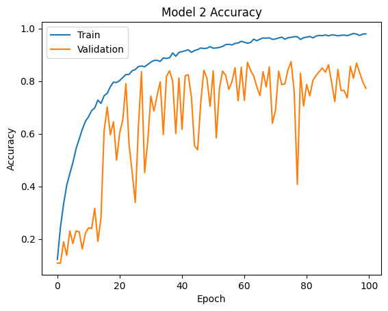

```python
# Plot the loss and accuracy of the model.
plt.plot(history_2.history['accuracy'])
plt.plot(history_2.history['val_accuracy'])
plt.title('Model 2 Accuracy')
plt.ylabel('Accuracy')
plt.xlabel('Epoch')
plt.legend(['Train', 'Validation'], loc='upper left')
plt.show()
```

#### **Observation**

- **Extended Training:** This model trained for nearly 100 epochs, much longer than any previous version we've seen.
- **Higher Final Performance:** Training accuracy reaches nearly 100%, and validation accuracy appears to average around 75-80% by the end, though with extreme fluctuations.
- **Extreme Validation Instability:** The validation accuracy shows dramatic oscillations throughout training, with swings of 20-50% between consecutive epochs in some cases. This level of instability is concerning and unusual.
- **Overall Trend:** Despite the volatility, there is a general upward trend in validation accuracy over time.

```python
# Evaluate the model on the test data
accuracy = model2.evaluate(X_test_normalized, y_test_binary, verbose=2)
```

```
30/30 - 1s - 35ms/step - accuracy: 0.7726 - loss: 1.0955
```

**Plotting the Confusion Matrix**

```python
# Get the output as probablities for each category.
y_pred=model2.predict(X_test_normalized)
```

```
30/30 ━━━━━━━━━━━━━━━━━━━━ 1s 21ms/step
```

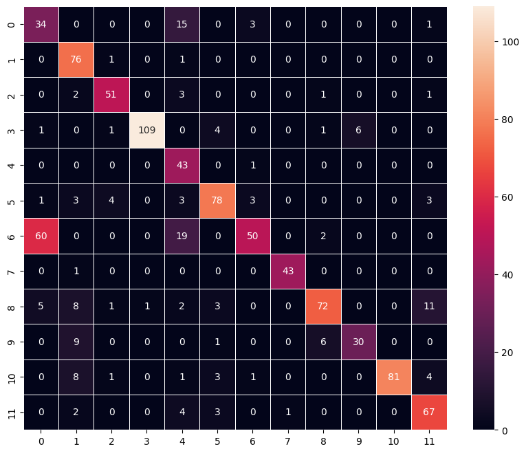

```python
# Obtaining the categorical values from y_test_binary and y_pred
y_pred_arg=np.argmax(y_pred,axis=1)
y_test_arg=np.argmax(y_test_binary,axis=1)

# Plotting the Confusion Matrix using confusion matrix() function which is also predefined tensorflow module
confusion_matrix = tf.math.confusion_matrix(y_test_arg,y_pred_arg)
f, ax = plt.subplots(figsize=(10, 8))
sns.heatmap(
    confusion_matrix,
    annot=True,
    linewidths=.4,
    fmt="d",
    square=True,
    ax=ax
)
plt.show()
```

```python
# Plotting the classification report
print("Model 2 Classification Report")
cr=metrics.classification_report(y_test_arg,y_pred_arg)
print(cr)
```

```
Model 2 Classification Report
              precision    recall  f1-score   support

           0       0.34      0.64      0.44        53
           1       0.70      0.97      0.81        78
           2       0.86      0.88      0.87        58
           3       0.99      0.89      0.94       122
           4       0.47      0.98      0.64        44
           5       0.85      0.82      0.83        95
           6       0.86      0.38      0.53       131
           7       0.98      0.98      0.98        44
           8       0.88      0.70      0.78       103
           9       0.83      0.65      0.73        46
          10       1.00      0.82      0.90        99
          11       0.77      0.87      0.82        77

    accuracy                           0.77       950
   macro avg       0.79      0.80      0.77       950
weighted avg       0.83      0.77      0.78       950
```

### **Data Augmentation**

Remember, **data augmentation should not be used in the validation/test data set**.

## Prepare Agumented data

- Creates augmented versions of the existing training images using ImageDataGenerator
- Applies more augmentations to underrepresented classes to help balance the dataset
- Combines the original and augmented data into a larger training set
- Preserves the correct labels for all images

After running this code, we will have X_train_augmented and y_train_augmented which we can use for training the model. This should help improve your model's performance, especially for the classes that had fewer samples in the original dataset.

```python
# from tensorflow.keras.preprocessing.image import ImageDataGenerator
# import numpy as np

# Create an ImageDataGenerator with augmentation settings
datagen = ImageDataGenerator(
    rotation_range=20,           # Randomly rotate images by 0-20 degrees
    width_shift_range=0.2,       # Randomly shift images horizontally
    height_shift_range=0.2,      # Randomly shift images vertically
    shear_range=0.2,             # Shear transformations
    zoom_range=0.2,              # Random zoom
    horizontal_flip=True,        # Randomly flip images horizontally
    fill_mode='nearest'          # Strategy for filling in newly created pixels
)

# Define how many augmented samples to generate per original image
augmentation_factor = 3  # Generate 3 new images per original image
augmented_images = []
augmented_labels = []

# Get the encoded labels from binary format
y_encoded = np.argmax(y_train_binary, axis=1)

# Get the number of classes
num_classes = y_train_binary.shape[1]
print(f"Number of classes: {num_classes}")

# Generate augmented samples
print("Generating augmented images...")

# Iterate through each class to balance the dataset
for class_idx in range(num_classes):
    # Get indices of images in this class
    class_indices = np.where(y_encoded == class_idx)[0]
    n_samples = len(class_indices)

    print(f"Class {class_idx}: Augmenting {n_samples} original images")

    # For classes with fewer samples, generate more augmentations
    class_aug_factor = augmentation_factor
    if n_samples < 300:  # Adjust threshold based on your dataset
        class_aug_factor = augmentation_factor * 2

    # Process images in this class
    for i, idx in enumerate(class_indices):
        img = X_train_normalized[idx]
        img = np.expand_dims(img, 0)  # Add batch dimension

        # Generate 'class_aug_factor' augmented versions of this image
        aug_iter = datagen.flow(img, batch_size=1)
        for j in range(class_aug_factor):
            aug_img = next(aug_iter)[0]  # Use next() instead of .next()
            augmented_images.append(aug_img)
            augmented_labels.append(y_train_binary[idx])  # Use the original one-hot encoded label

# Convert to numpy arrays
augmented_images = np.array(augmented_images)
augmented_labels = np.array(augmented_labels)

# Combine original and augmented data
X_train_augmented = np.vstack((X_train_normalized, augmented_images))
y_train_augmented = np.vstack((y_train_binary, augmented_labels))

print("=======================================")
print(f"Original training set: {X_train_normalized.shape[0]} images")
print(f"Augmented images: {augmented_images.shape[0]} images")
print(f"Combined training set: {X_train_augmented.shape[0]} images")
print("=======================================")

# Verify class distribution after augmentation
y_augmented_encoded = np.argmax(y_train_augmented, axis=1)
unique, counts = np.unique(y_augmented_encoded, return_counts=True)
print("\nClass distribution after augmentation:")
for i, (class_idx, count) in enumerate(zip(unique, counts)):
    print(f"Class {class_idx}: {count} images")
```

```
Number of classes: 12
Generating augmented images...
Class 0: Augmenting 157 original images
Class 1: Augmenting 234 original images
Class 2: Augmenting 172 original images
Class 3: Augmenting 367 original images
Class 4: Augmenting 133 original images
Class 5: Augmenting 285 original images
Class 6: Augmenting 392 original images
Class 7: Augmenting 133 original images
Class 8: Augmenting 310 original images
Class 9: Augmenting 139 original images
Class 10: Augmenting 297 original images
Class 11: Augmenting 231 original images
=======================================
Original training set: 2850 images
Augmented images: 13893 images
Combined training set: 16743 images
=======================================

Class distribution after augmentation:
Class 0: 1099 images
Class 1: 1638 images
Class 2: 1204 images
Class 3: 1468 images
Class 4: 931 images
Class 5: 1995 images
Class 6: 1568 images
Class 7: 931 images
Class 8: 1240 images
Class 9: 973 images
Class 10: 2079 images
Class 11: 1617 images
```

#### **Observation**

=======================================

Original training set: 2850 images

Augmented images: 13893 images

**Combined training set: 16743 images**

=======================================

### **Model 3**

1. Takes input images of shape (64, 64, 3)
2. Uses 3x3 kernels for all convolutional layers as specified
3. Includes 4 convolutional blocks, each reducing spatial dimensions until you reach 4x4 feature maps
4. Starting with 64x64 → 32x32 → 16x16 → 8x8 → 4x4
5. Uses increasing filter counts (32, 64, 96, 128) to extract more complex features
6. Incorporates BatchNormalization for faster training and better generalization
7. Uses Dropout to prevent overfitting
8. Has two dense layers before the final output layer 1.Uses softmax activation for multi-class classification with 12 output neurons
9. Is compiled with Adam optimizer and categorical crossentropy loss
10. **We will use the Data agumented training dataset**

```python
# Clearing backend
backend.clear_session()
```

```python
# Fixing the seed for random number generators
np.random.seed(124)
random.seed(124)
tf.random.set_seed(124)
```

```python
# Define input shape
input_shape = (64, 64, 3)

# Create the CNN model
model3 = Sequential()

# First convolutional block
model3.add(Conv2D(32, kernel_size=(3, 3), activation='relu', padding='same', input_shape=input_shape))
model3.add(BatchNormalization())
model3.add(MaxPooling2D(pool_size=(2, 2)))
model3.add(Dropout(0.25))

# Second convolutional block
model3.add(Conv2D(64, kernel_size=(3, 3), activation='relu', padding='same'))
model3.add(BatchNormalization())
model3.add(MaxPooling2D(pool_size=(2, 2)))
model3.add(Dropout(0.25))

# Third convolutional block
model3.add(Conv2D(96, kernel_size=(3, 3), activation='relu', padding='same'))
model3.add(BatchNormalization())
model3.add(MaxPooling2D(pool_size=(2, 2)))
model3.add(Dropout(0.25))

# Fourth convolutional block - this will reduce to 4x4 feature maps
model3.add(Conv2D(128, kernel_size=(3, 3), activation='relu', padding='same'))
model3.add(BatchNormalization())
model3.add(MaxPooling2D(pool_size=(2, 2)))
model3.add(Dropout(0.25))

# Flatten the feature maps
model3.add(Flatten())

# Fully connected layers
model3.add(Dense(100, activation='relu'))
model3.add(BatchNormalization())
model3.add(Dropout(0.5))
model3.add(Dense(100, activation='relu'))
model3.add(BatchNormalization())
model3.add(Dropout(0.5))

# Output layer with 12 neurons (one for each plant class)
model3.add(Dense(12, activation='softmax'))

# Compile the model
model3.compile(
    optimizer=Adam(learning_rate=0.001),
    loss='categorical_crossentropy',
    metrics=['accuracy']
)

# Print model summary
model3.summary()
```

```
Model: "sequential"
```

```
┏━━━━━━━━━━━━━━━━━━━━━━━━━━━━━━━━━━━━━━┳━━━━━━━━━━━━━━━━━━━━━━━━━━━━━┳━━━━━━━━━━━━━━━━━┓
┃ Layer (type)                         ┃ Output Shape                ┃         Param # ┃
┡━━━━━━━━━━━━━━━━━━━━━━━━━━━━━━━━━━━━━━╇━━━━━━━━━━━━━━━━━━━━━━━━━━━━━╇━━━━━━━━━━━━━━━━━┩
│ conv2d (Conv2D)                      │ (None, 64, 64, 32)          │             896 │
├──────────────────────────────────────┼─────────────────────────────┼─────────────────┤
│ batch_normalization                  │ (None, 64, 64, 32)          │             128 │
│ (BatchNormalization)                 │                             │                 │
├──────────────────────────────────────┼─────────────────────────────┼─────────────────┤
│ max_pooling2d (MaxPooling2D)         │ (None, 32, 32, 32)          │               0 │
├──────────────────────────────────────┼─────────────────────────────┼─────────────────┤
│ dropout (Dropout)                    │ (None, 32, 32, 32)          │               0 │
├──────────────────────────────────────┼─────────────────────────────┼─────────────────┤
│ conv2d_1 (Conv2D)                    │ (None, 32, 32, 64)          │          18,496 │
├──────────────────────────────────────┼─────────────────────────────┼─────────────────┤
│ batch_normalization_1                │ (None, 32, 32, 64)          │             256 │
│ (BatchNormalization)                 │                             │                 │
├──────────────────────────────────────┼─────────────────────────────┼─────────────────┤
│ max_pooling2d_1 (MaxPooling2D)       │ (None, 16, 16, 64)          │               0 │
├──────────────────────────────────────┼─────────────────────────────┼─────────────────┤
│ dropout_1 (Dropout)                  │ (None, 16, 16, 64)          │               0 │
├──────────────────────────────────────┼─────────────────────────────┼─────────────────┤
│ conv2d_2 (Conv2D)                    │ (None, 16, 16, 96)          │          55,392 │
├──────────────────────────────────────┼─────────────────────────────┼─────────────────┤
│ batch_normalization_2                │ (None, 16, 16, 96)          │             384 │
│ (BatchNormalization)                 │                             │                 │
├──────────────────────────────────────┼─────────────────────────────┼─────────────────┤
│ max_pooling2d_2 (MaxPooling2D)       │ (None, 8, 8, 96)            │               0 │
├──────────────────────────────────────┼─────────────────────────────┼─────────────────┤
│ dropout_2 (Dropout)                  │ (None, 8, 8, 96)            │               0 │
├──────────────────────────────────────┼─────────────────────────────┼─────────────────┤
│ conv2d_3 (Conv2D)                    │ (None, 8, 8, 128)           │         110,720 │
├──────────────────────────────────────┼─────────────────────────────┼─────────────────┤
│ batch_normalization_3                │ (None, 8, 8, 128)           │             512 │
│ (BatchNormalization)                 │                             │                 │
├──────────────────────────────────────┼─────────────────────────────┼─────────────────┤
│ max_pooling2d_3 (MaxPooling2D)       │ (None, 4, 4, 128)           │               0 │
├──────────────────────────────────────┼─────────────────────────────┼─────────────────┤
│ dropout_3 (Dropout)                  │ (None, 4, 4, 128)           │               0 │
├──────────────────────────────────────┼─────────────────────────────┼─────────────────┤
│ flatten (Flatten)                    │ (None, 2048)                │               0 │
├──────────────────────────────────────┼─────────────────────────────┼─────────────────┤
│ dense (Dense)                        │ (None, 100)                 │         204,900 │
├──────────────────────────────────────┼─────────────────────────────┼─────────────────┤
│ batch_normalization_4                │ (None, 100)                 │             400 │
│ (BatchNormalization)                 │                             │                 │
├──────────────────────────────────────┼─────────────────────────────┼─────────────────┤
│ dropout_4 (Dropout)                  │ (None, 100)                 │               0 │
├──────────────────────────────────────┼─────────────────────────────┼─────────────────┤
│ dense_1 (Dense)                      │ (None, 100)                 │          10,100 │
├──────────────────────────────────────┼─────────────────────────────┼─────────────────┤
│ batch_normalization_5                │ (None, 100)                 │             400 │
│ (BatchNormalization)                 │                             │                 │
├──────────────────────────────────────┼─────────────────────────────┼─────────────────┤
│ dropout_5 (Dropout)                  │ (None, 100)                 │               0 │
├──────────────────────────────────────┼─────────────────────────────┼─────────────────┤
│ dense_2 (Dense)                      │ (None, 12)                  │           1,212 │
└──────────────────────────────────────┴─────────────────────────────┴─────────────────┘
```

```
 Total params: 403,796 (1.54 MB)
```

```
 Trainable params: 402,756 (1.54 MB)
```

```
 Non-trainable params: 1,040 (4.06 KB)
```

```python
# Fit the model on train and validation data.
history_3 = model3.fit(
            X_train_augmented, y_train_augmented,
            epochs=100,
            validation_data=(X_val_normalized,y_val_binary),
            batch_size=64,
            callbacks=[reduce_lr],
            verbose=2
)
```

```
262/262 - 19s - 74ms/step - accuracy: 0.2514 - loss: 2.4467 - val_accuracy: 0.0463 - val_loss: 4.3647 - learning_rate: 0.0010
262/262 - 1s - 6ms/step - accuracy: 0.4586 - loss: 1.5392 - val_accuracy: 0.1632 - val_loss: 3.7914 - learning_rate: 0.0010
262/262 - 1s - 5ms/step - accuracy: 0.5765 - loss: 1.2232 - val_accuracy: 0.5411 - val_loss: 1.2227 - learning_rate: 0.0010
262/262 - 1s - 5ms/step - accuracy: 0.6465 - loss: 1.0101 - val_accuracy: 0.6032 - val_loss: 1.1578 - learning_rate: 0.0010
262/262 - 1s - 5ms/step - accuracy: 0.7013 - loss: 0.8540 - val_accuracy: 0.3600 - val_loss: 2.0790 - learning_rate: 0.0010
262/262 - 1s - 5ms/step - accuracy: 0.7488 - loss: 0.7248 - val_accuracy: 0.7021 - val_loss: 0.7932 - learning_rate: 0.0010
262/262 - 1s - 5ms/step - accuracy: 0.7856 - loss: 0.6179 - val_accuracy: 0.7663 - val_loss: 0.6589 - learning_rate: 0.0010
262/262 - 1s - 5ms/step - accuracy: 0.8101 - loss: 0.5339 - val_accuracy: 0.8316 - val_loss: 0.4830 - learning_rate: 0.0010
262/262 - 1s - 5ms/step - accuracy: 0.8331 - loss: 0.4799 - val_accuracy: 0.7842 - val_loss: 0.6460 - learning_rate: 0.0010
262/262 - 1s - 5ms/step - accuracy: 0.8461 - loss: 0.4383 - val_accuracy: 0.8453 - val_loss: 0.4384 - learning_rate: 0.0010
262/262 - 1s - 5ms/step - accuracy: 0.8628 - loss: 0.3866 - val_accuracy: 0.8368 - val_loss: 0.4108 - learning_rate: 0.0010
262/262 - 1s - 5ms/step - accuracy: 0.8721 - loss: 0.3682 - val_accuracy: 0.8032 - val_loss: 0.7477 - learning_rate: 0.0010
262/262 - 1s - 5ms/step - accuracy: 0.8736 - loss: 0.3534 - val_accuracy: 0.8200 - val_loss: 0.4826 - learning_rate: 0.0010
262/262 - 1s - 5ms/step - accuracy: 0.8891 - loss: 0.3136 - val_accuracy: 0.8179 - val_loss: 0.6195 - learning_rate: 0.0010
262/262 - 1s - 5ms/step - accuracy: 0.8924 - loss: 0.2985 - val_accuracy: 0.7032 - val_loss: 1.1572 - learning_rate: 0.0010

Epoch 16: ReduceLROnPlateau reducing learning rate to 0.00020000000949949026.
262/262 - 1s - 5ms/step - accuracy: 0.9036 - loss: 0.2818 - val_accuracy: 0.7737 - val_loss: 0.7668 - learning_rate: 0.0010
262/262 - 1s - 5ms/step - accuracy: 0.9201 - loss: 0.2254 - val_accuracy: 0.9379 - val_loss: 0.1933 - learning_rate: 2.0000e-04
262/262 - 1s - 5ms/step - accuracy: 0.9295 - loss: 0.1973 - val_accuracy: 0.9411 - val_loss: 0.1812 - learning_rate: 2.0000e-04
262/262 - 1s - 5ms/step - accuracy: 0.9340 - loss: 0.1855 - val_accuracy: 0.9284 - val_loss: 0.2081 - learning_rate: 2.0000e-04
262/262 - 1s - 5ms/step - accuracy: 0.9356 - loss: 0.1780 - val_accuracy: 0.9421 - val_loss: 0.1829 - learning_rate: 2.0000e-04
262/262 - 1s - 5ms/step - accuracy: 0.9394 - loss: 0.1759 - val_accuracy: 0.9368 - val_loss: 0.1903 - learning_rate: 2.0000e-04
262/262 - 1s - 5ms/step - accuracy: 0.9444 - loss: 0.1611 - val_accuracy: 0.9400 - val_loss: 0.1883 - learning_rate: 2.0000e-04

Epoch 23: ReduceLROnPlateau reducing learning rate to 4.0000001899898055e-05.
262/262 - 1s - 5ms/step - accuracy: 0.9439 - loss: 0.1547 - val_accuracy: 0.9379 - val_loss: 0.1957 - learning_rate: 2.0000e-04
262/262 - 1s - 5ms/step - accuracy: 0.9510 - loss: 0.1441 - val_accuracy: 0.9379 - val_loss: 0.1917 - learning_rate: 4.0000e-05
262/262 - 1s - 5ms/step - accuracy: 0.9526 - loss: 0.1380 - val_accuracy: 0.9253 - val_loss: 0.2461 - learning_rate: 4.0000e-05
262/262 - 1s - 5ms/step - accuracy: 0.9531 - loss: 0.1396 - val_accuracy: 0.9400 - val_loss: 0.1901 - learning_rate: 4.0000e-05
262/262 - 1s - 5ms/step - accuracy: 0.9522 - loss: 0.1385 - val_accuracy: 0.9358 - val_loss: 0.1978 - learning_rate: 4.0000e-05

Epoch 28: ReduceLROnPlateau reducing learning rate to 8.000000525498762e-06.
262/262 - 1s - 5ms/step - accuracy: 0.9506 - loss: 0.1403 - val_accuracy: 0.9242 - val_loss: 0.2370 - learning_rate: 4.0000e-05
262/262 - 1s - 5ms/step - accuracy: 0.9525 - loss: 0.1324 - val_accuracy: 0.9358 - val_loss: 0.1986 - learning_rate: 8.0000e-06
262/262 - 1s - 5ms/step - accuracy: 0.9563 - loss: 0.1307 - val_accuracy: 0.9368 - val_loss: 0.1986 - learning_rate: 8.0000e-06
262/262 - 1s - 5ms/step - accuracy: 0.9522 - loss: 0.1385 - val_accuracy: 0.9347 - val_loss: 0.2013 - learning_rate: 8.0000e-06
262/262 - 1s - 5ms/step - accuracy: 0.9540 - loss: 0.1341 - val_accuracy: 0.9389 - val_loss: 0.1847 - learning_rate: 8.0000e-06

Epoch 33: ReduceLROnPlateau reducing learning rate to 1.6000001778593287e-06.
```

[output cut: 55 more lines]

```
262/262 - 1s - 5ms/step - accuracy: 0.9549 - loss: 0.1289 - val_accuracy: 0.9368 - val_loss: 0.1989 - learning_rate: 1.0000e-06
262/262 - 1s - 5ms/step - accuracy: 0.9539 - loss: 0.1293 - val_accuracy: 0.9368 - val_loss: 0.1997 - learning_rate: 1.0000e-06
262/262 - 1s - 5ms/step - accuracy: 0.9559 - loss: 0.1283 - val_accuracy: 0.9379 - val_loss: 0.1972 - learning_rate: 1.0000e-06
262/262 - 1s - 5ms/step - accuracy: 0.9579 - loss: 0.1276 - val_accuracy: 0.9379 - val_loss: 0.1990 - learning_rate: 1.0000e-06
262/262 - 1s - 5ms/step - accuracy: 0.9550 - loss: 0.1295 - val_accuracy: 0.9379 - val_loss: 0.1980 - learning_rate: 1.0000e-06
262/262 - 1s - 5ms/step - accuracy: 0.9559 - loss: 0.1289 - val_accuracy: 0.9368 - val_loss: 0.1993 - learning_rate: 1.0000e-06
262/262 - 1s - 5ms/step - accuracy: 0.9545 - loss: 0.1319 - val_accuracy: 0.9368 - val_loss: 0.1992 - learning_rate: 1.0000e-06
262/262 - 1s - 5ms/step - accuracy: 0.9564 - loss: 0.1273 - val_accuracy: 0.9368 - val_loss: 0.2003 - learning_rate: 1.0000e-06
262/262 - 1s - 5ms/step - accuracy: 0.9541 - loss: 0.1302 - val_accuracy: 0.9379 - val_loss: 0.1981 - learning_rate: 1.0000e-06
262/262 - 1s - 5ms/step - accuracy: 0.9532 - loss: 0.1316 - val_accuracy: 0.9379 - val_loss: 0.1983 - learning_rate: 1.0000e-06
262/262 - 1s - 5ms/step - accuracy: 0.9553 - loss: 0.1291 - val_accuracy: 0.9379 - val_loss: 0.1991 - learning_rate: 1.0000e-06
262/262 - 1s - 5ms/step - accuracy: 0.9571 - loss: 0.1287 - val_accuracy: 0.9379 - val_loss: 0.1957 - learning_rate: 1.0000e-06
262/262 - 1s - 5ms/step - accuracy: 0.9555 - loss: 0.1280 - val_accuracy: 0.9379 - val_loss: 0.1973 - learning_rate: 1.0000e-06
262/262 - 1s - 5ms/step - accuracy: 0.9544 - loss: 0.1281 - val_accuracy: 0.9379 - val_loss: 0.1977 - learning_rate: 1.0000e-06
262/262 - 1s - 5ms/step - accuracy: 0.9578 - loss: 0.1252 - val_accuracy: 0.9368 - val_loss: 0.1999 - learning_rate: 1.0000e-06
```

**Model Evaluation**

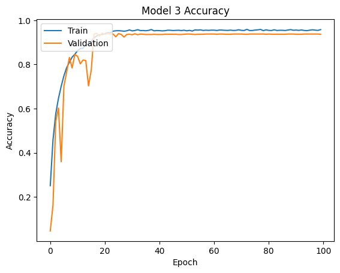

```python
# Plot the loss and accuracy of the model.
plt.plot(history_3.history['accuracy'])
plt.plot(history_3.history['val_accuracy'])
plt.title('Model 3 Accuracy')
plt.ylabel('Accuracy')
plt.xlabel('Epoch')
plt.legend(['Train', 'Validation'], loc='upper left')
plt.show()
```